# A3 Report

Paul Kim

2/16/2022

## **Introduction**

This report aims to explore trends regarding the population counts of specific races within the United States jail system. This report focuses primarily on the counts of Asian American & Pacific Islander (AA/PI) inmates within specific areas and times. The decision to focus on AA/PI trends is due to the author’s own race being AA/PI. The author is also simply curious on how the AA/PI race fares in this part of American society. This report additionally provides some comparisons between AA/PI counts and the Black and White races. Trends are explored through both individual calculated values and various visualizations.

### **Summary Information**

Given the very large nature of the dataset, I decided to take a more in-depth, focused look on the AA/PI values. I first sought to find the count of the highest amount of AA/PI inmates within a specific county jail, which turned out to be **893**. I also decided to find the county which housed these 893 inmates in order to better understand the geographical area in which they reside. The county with the highest count of AA/PI inmates within the year ranges of the data is **Los Angeles County**. I wanted to find the average amount of AA/PI inmates the Los Angeles County jail held across time to understand whether the count of 893 I found earlier was just an unusually high number or a normal AA/PI count for the Los Angeles County jail. This average turned out to be **238.88**, which is significantly lower than 893. This may indicate that the year in which the highest count for AA/PI inmates was recorded may have certain significance in Los Angeles County, such as the 1992 LA riots. After understanding these preliminary pieces of data for the AA/PI population, I wanted to see how it compared to the Black population. I first found that **Los Angeles County** is also the county which housed the largest amount of Black inmates within the year ranges the data provides. I also then wanted to see the average amount of Black inmates in the Los Angeles County jail across time in order to compare the average to the AA/PI average. This average turned out to be **6645.95**. An initial observation is that though both AA/PI and Black inmates share the same county where their jail count is the highest, the Black inmate average is much higher.

### **Visualizations of Data**

#### *What is the trend for the population of AA/PI, White, and Black jail inmates in Los Angeles County over the last 10 years?*

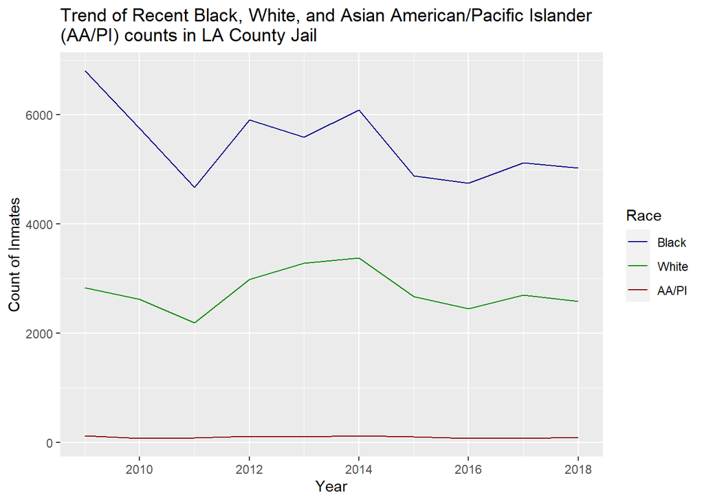

#### *Within the most recent year in California, what is the relationship between total population counts of AA/PI citizens per county and jail population counts of AA/PI inmates per county?*

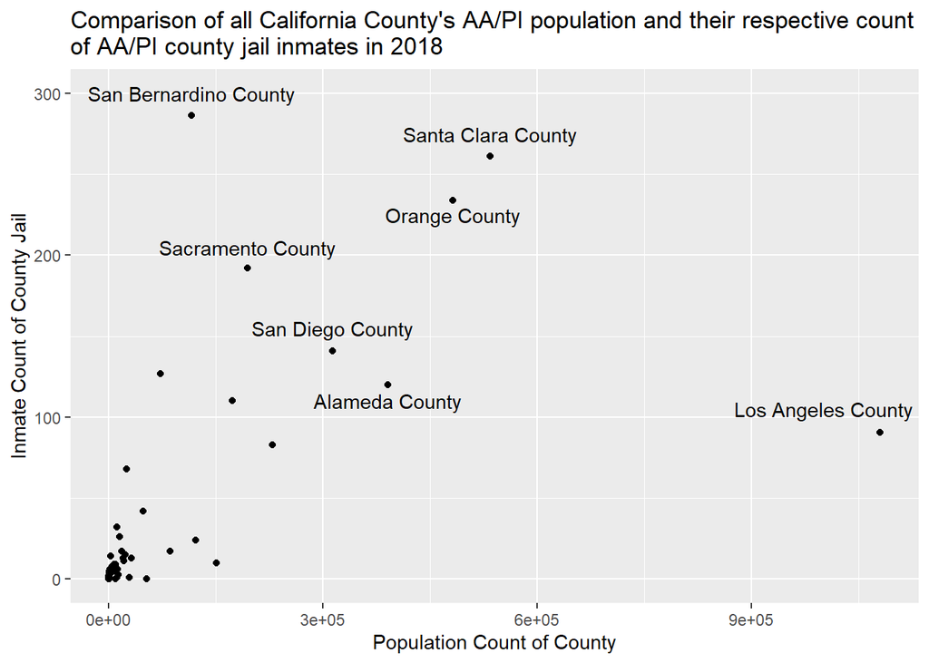

#### *In the year in which the AA/PI jail population was at it highest, what is the trend of AA/PI jail counts across the United States by state?*

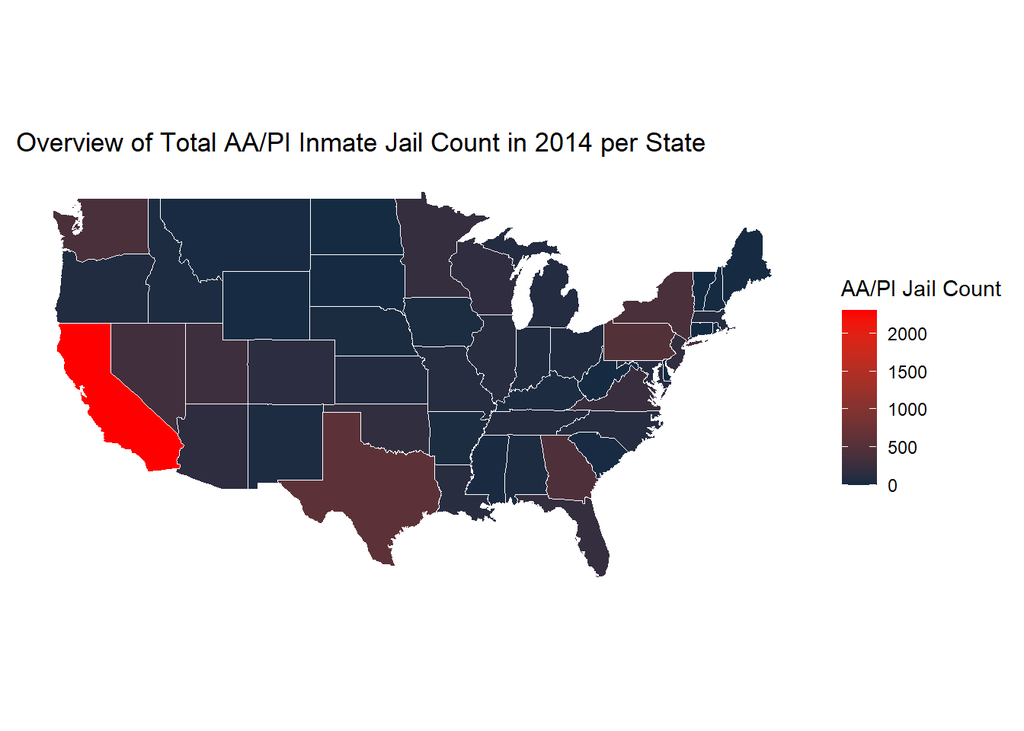

Much of the analysis has been centered on the State of California. This map chart aims to take a look at the trends of AA/PI inmates across the entire nation in the year where the AA/PI inmate count was at it’s highest. This map chart clearly showcases California as the state with the highest total AA/PI inmate count, but some other notable information appears as well. States such as Washington, Texas, Nevada, and Georgia seem to have sizable counts of AA/PI inmates, while states like Idaho, Montana, and Oregon seem to have a smaller AA/PI inmate count comparatively. The map additionally shows that the count of AA/PI inmates is concentrated primarily within California, with the rest of the United States owning a relatively smaller amount of AA/PI inmates. This may showcase the potential over-policing of citizens in the State of California.